# Quantile Binning for Microbiome ML

EuroBioC2026 — Results Report

Author

Affiliation

Rasmus Hindström

Department of Computing, University of Turku

Published

May 13, 2026

# 1 Dataset overview

**NotePipeline parameters**

| Parameter | Value |
| --- | --- |
| Min samples per class (`min_class_n`) | 50 |
| n_bins candidates (`n_bins_levels`) | 9 (log₂-spaced) |
| n_bins range (`n_bins_range`) | 1–50 |
| CV folds (inner & outer) | 5 |
| Classifiers | Random Forest (`ranger`), Regularised logistic regression (`glmnet`), Radial SVM (`kernlab`) |
| Transformations | TSS, rCLR, presence/absence, quantile binning |
| Tuning metric | ROC-AUC (inner CV) |

Table 1: Datasets after filtering (min 50 samples per class): n = 24

| Sequencing type | Datasets |
| --- | --- |
| sg | 13 |
| 16s | 11 |

# 2 Preprocessing pipeline

All datasets are agglomerated to genus level before any modelling. The table below summarises which recipe steps are applied to each classifier, followed by the rationale for each design decision.

Table 2: Recipe steps by classifier class

| Step | RF | glmnet | svm_rbf |
| --- | --- | --- | --- |
| Genus-level agglomeration | ✓ | ✓ | ✓ |
| Feature transformation | ✓ | ✓ | ✓ |
| Zero-variance filter | ✓ | ✓ | ✓ |
| Z-score normalisation | — | ✓ | ✓ |

## 2.1 Genus-level agglomeration

Raw count tables contain taxa resolved to varying depths. Agglomerating to genus level reduces dimensionality, smooths over uncertain species-level assignments, and gives each transformation a consistent feature space across datasets.

## 2.2 Feature transformations

All transformations are sample-wise: no cross-sample statistics are computed, so they are safe to apply before the train/test split and inside inner CV folds without leakage.

## 2.3 Zero-variance filtering

`step_zv()` drops any feature whose values are identical across all training samples in a given fold. This can occur after binning (many taxa collapse to all-zero bins) and occasionally with presence/absence on extremely prevalent or extremely rare taxa. Using exact zero-variance rather than the near-zero-variance heuristic (`step_nzv`) avoids silently discarding rare-but-present taxa whose low frequency ratios could still carry signal—a meaningful distinction in sparse microbiome data.

## 2.4 Z-score normalisation

**glmnet (elastic net):** The $L_1$ and $L_2$ penalties shrink coefficients toward zero. Without standardisation, features on a larger numerical scale receive a proportionally smaller effective penalty and are therefore systematically favoured, which confounds the regularisation path. Standardisation ensures that the penalty acts uniformly across features.

**svm_rbf (radial SVM):** The RBF kernel $k(\mathbf{x}, \mathbf{x}') = \exp(-\sigma \|\mathbf{x} - \mathbf{x}'\|^2)$ measures Euclidean distance in feature space. Features with large variances dominate the distance calculation regardless of their biological relevance. Standardisation makes the kernel sensitive to the relative, not absolute, spread of each feature.

**NoteScaling ordinal bin labels**

When the binning transformation is combined with z-score normalisation, the recipe standardises ordinal integers (0, 1, 2, …, $n_\text{bins}$) rather than continuous abundances. Two properties of the binned representation make this well-behaved. First, the bins are **equally spaced** on an ordinal scale — each step from bin $k$ to $k+1$ represents the same rank increase — so treating the integers as a continuous scale is a reasonable approximation, and linear centering/scaling preserves that spacing. Second, zeros (absent taxa) remain distinguishable from bin 1 (lowest-abundance detected taxa) after scaling, because 0 is a structurally distinct value that maps to a standardised score well below the non-zero bin means. The practical consequence is that the penalty (glmnet) or distance kernel (svm_rbf) sees a feature space where each taxon’s bin label has been placed on a common variance-1 scale — the same regularisation assumptions that justify normalising continuous features apply here.

**Random Forest** does not receive normalisation. Decision trees split on individual feature thresholds; they are invariant to any monotone transformation of a feature’s values, including centering and scaling. Adding normalisation to RF would be harmless but adds unnecessary computation.

# 3 Overall performance

Three classifiers are compared across all transformation × dataset combinations. **Random Forest** (RF, `ranger`) is a bagging ensemble of decision trees; it handles high-dimensional, sparse count data well and requires minimal preprocessing. **Regularised logistic regression** (`glmnet`) fits an elastic-net penalised linear model; features are standardised before fitting. **Radial basis function SVM** (`kernlab`) uses an RBF kernel to separate classes in a high-dimensional feature space; it also requires standardised inputs.

**NoteROC-AUC**

Area under the receiver operating characteristic curve. Measures the probability that the model ranks a random case higher than a random control. Ranges from 0.5 (random) to 1.0 (perfect). **Used as the inner-CV tuning metric** because it is threshold-independent and robust to class imbalance.

**NoteAccuracy**

Proportion of samples correctly classified. Intuitive, but sensitive to class imbalance — a model that always predicts the majority class can score high without being useful.

**NoteCohen’s κ (Kappa)**

Adjusts accuracy for the agreement expected by chance given the observed class frequencies. Values near 0 indicate chance-level performance; values near 1 indicate near-perfect discrimination. More informative than raw accuracy when classes are imbalanced.

Each point below is one dataset. Boxplots summarise the spread across all datasets. AUC is shown first; Accuracy and Kappa follow in separate plots. Binning is highlighted; its box should sit at or above the alternatives if it is competitive.

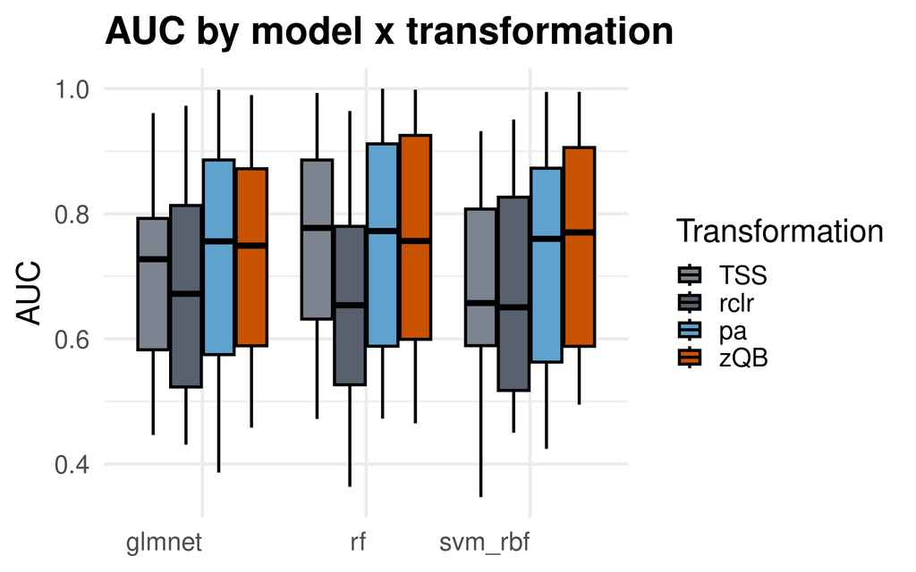

Figure 1

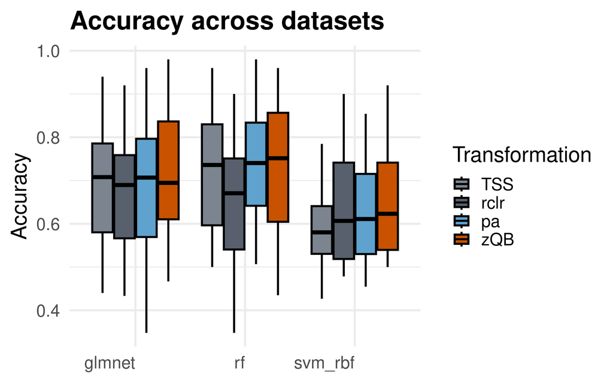

Figure 2

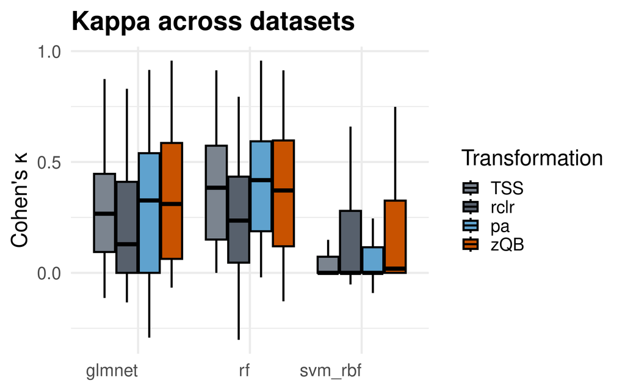

Figure 3

# 4 Binning vs. PA

## 4.1 Per-dataset comparison: binning vs. PA

For each dataset × classifier, we compute **Δ AUC = AUC(zQB) − AUC(PA)**. Red cells mean zQB wins on that dataset; blue cells mean a standard transformation does better.

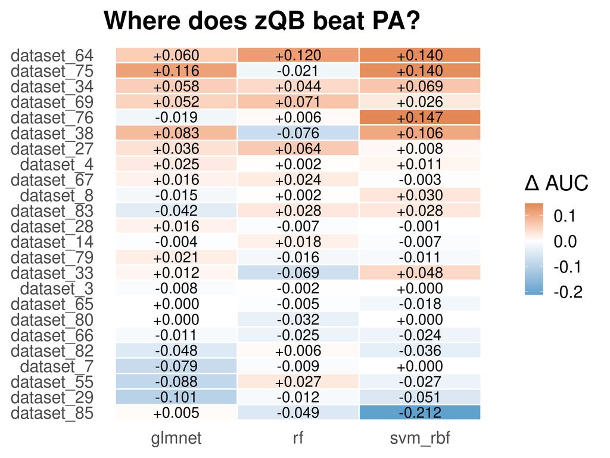

Figure 4

## 4.2 Head-to-head scatter

Binning AUC vs. each alternative, point-by-point. Points above the diagonal mean binning wins on that (dataset, classifier) pair.

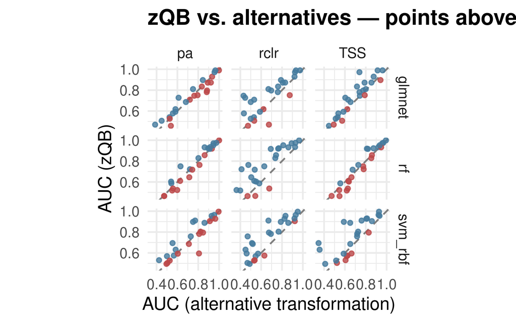

Figure 5

# 5 Binning internals

## 5.1 Selected `n_bins` distribution

Which bin counts did the inner CV pick? A tight distribution suggests a sweet spot; a flat one suggests `n_bins` doesn’t matter much.

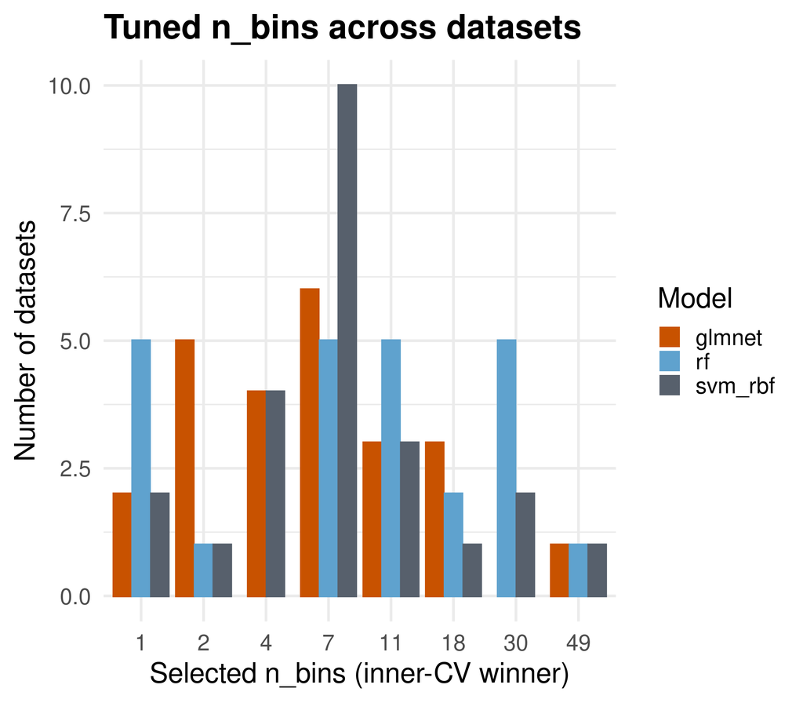

Figure 6

# 6 Statistical comparison

Friedman test (non-parametric repeated-measures) treats each dataset as a block and tests whether any transformation ranks consistently higher by AUC. Pairwise Wilcoxon signed-rank tests (Holm-adjusted) follow up on the omnibus result. Each cell shows the significance level and the mean AUC difference (row − column); red cells favour the row transformation, blue cells favour the column transformation.

Table 3: Friedman test: are transformation AUC ranks non-random?

| Classifier | χ² | df | p-value |
| --- | --- | --- | --- |
| glmnet | 16.08 | 3 | 0.0011 |
| rf | 18.56 | 3 | 0.0003 |
| svm_rbf | 18.52 | 3 | 0.0003 |

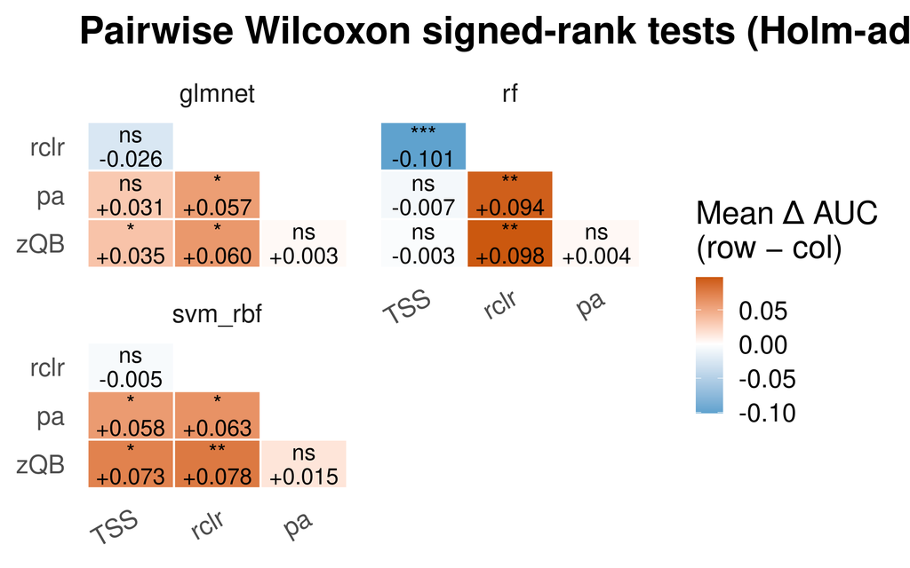

Figure 7

# 7 Summary table

Mean [95% CI] for AUC, Accuracy, and Kappa per classifier × transformation across all datasets, sorted by mean AUC descending. CIs are t-based across datasets.

Table 4: Mean [95% CI] across datasets (t-distribution, per classifier × transformation)

| Classifier | Transformation | AUC | Accuracy | Kappa |
| --- | --- | --- | --- | --- |
| glmnet | zQB | 0.736 [0.665–0.807] | 0.709 [0.648–0.770] | 0.347 [0.216–0.477] |
| glmnet | pa | 0.732 [0.655–0.809] | 0.691 [0.626–0.756] | 0.307 [0.172–0.441] |
| glmnet | TSS | 0.701 [0.638–0.764] | 0.690 [0.635–0.745] | 0.303 [0.194–0.411] |
| glmnet | rclr | 0.675 [0.600–0.751] | 0.668 [0.612–0.725] | 0.226 [0.108–0.344] |
| rf | TSS | 0.758 [0.692–0.825] | 0.727 [0.669–0.784] | 0.384 [0.261–0.506] |
| rf | zQB | 0.755 [0.678–0.832] | 0.722 [0.660–0.785] | 0.379 [0.249–0.509] |
| rf | pa | 0.751 [0.677–0.825] | 0.734 [0.680–0.788] | 0.402 [0.287–0.518] |
| rf | rclr | 0.657 [0.580–0.734] | 0.651 [0.591–0.711] | 0.243 [0.122–0.364] |
| svm_rbf | zQB | 0.746 [0.674–0.818] | 0.653 [0.599–0.707] | 0.189 [0.079–0.299] |
| svm_rbf | pa | 0.731 [0.656–0.806] | 0.621 [0.576–0.667] | 0.095 [0.013–0.176] |
| svm_rbf | TSS | 0.673 [0.602–0.744] | 0.598 [0.560–0.636] | 0.045 [0.003–0.086] |
| svm_rbf | rclr | 0.668 [0.594–0.741] | 0.638 [0.582–0.695] | 0.151 [0.038–0.265] |